V The V Lab

# Poisson 回归与零膨胀模型详解

从事件率、暴露时间与过度离散到零膨胀 Poisson 的估计、诊断和报告

公共卫生学院学习模块

更新于 2026年08月12日

**适用对象**公共卫生、流行病学、医学与健康数据科学学习者

**学习时长**约 150–210 分钟

**先修要求**描述统计、线性/逻辑回归基础与基本 R 语法

本教程的数据与目标 所有数据均由固定随机种子模拟：2,400 名成人在不同人年中发生的呼吸系统急诊（ED）就诊次数。部分人不在参与医疗机构的资料捕获范围内，因此必为零；其他人即使在范围内，也可能只是观察期内恰好没有就诊。这个刻意设置让我们区分**结构零**和**抽样零**，但绝不把模拟中的机制直接当成真实世界结论。

先问研究设计，再选模型 Poisson、负二项、hurdle 和 ZIP 都是结局分布模型；它们不会自动处理混杂、重复测量、选择进入队列、缺失或错误的随访起点。若“预防项目”不是随机分配，本页调整后的 IRR 仍是条件关联，不能仅凭模型名称解读为因果效应。

## 如何使用本教程

建议沿着以下链条学习：

> **计数问题与分母 → Poisson 模型 → 率比和绝对预测 → 离散度 → 负二项/稳健推断 → 零的机制 → ZIP 估计与预测 → 频数校准 → 报告与研究边界**

### 学习目标

完成本教程后，你应能够：

- 区分事件**次数**、事件**率**、二分类**风险**和随访**暴露时间**；
- 用 `offset(log(person_years))` 建立以人年为分母的 Poisson 率模型；
- 把回归系数转换为 IRR、置信区间，并报告有政策意义的绝对预测；
- 用 Pearson 离散度评估 Poisson 的均值—方差约束，理解过度离散的常见来源；
- 在 `glm()` Poisson、quasi-Poisson 和 `MASS::glm.nb()` 之间作有目的的选择；
- 解释“零很多”为什么不是 ZIP 的充分证据；
- 写出 ZIP 的双部分似然，并使用 base R 的 `optim()` 实际估计一个 ZIP 模型；
- 分别解释在风险组的条件均值 $\mu$、结构零概率 $\pi$、边际均值及零概率；
- 用观测—预测频数、零比例和分组校准检查模型，而不迷信单一 AIC；
- 说明 hurdle、聚类模型和因果设计与普通 ZIP 的不同职责；
- 写出可复核的分析流程、结果段落与敏感性分析清单。

# 1 计数、率、风险：先把问题说清楚

## 1.1 同一个“零”可回答不同的问题

令 $Y_i$ 为第 $i$ 人在观察窗内的呼吸系统 ED 就诊次数，$t_i$ 为实际观察到的人年。

| 量 | 例子 | 合适的分母/模型 | 常见误解 |
| --- | --- | --- | --- |
| 次数 | 一年内 ED 就诊 0、1、2 次 | 计数模型 | 把 2 次当成“有病”二元变量 |
| 率 | 每人年 ED 就诊次数 | `offset(log(t))` 的 Poisson/负二项 | 忽略 0.3 年与 3 年随访不同 |
| 风险 | 一年内是否至少一次就诊 | 二项/逻辑或风险模型 | 将“至少一次”与次数混用 |
| 强度/发生率 | 瞬时事件过程 | 生存/复发事件方法 | 把删失当成完整暴露 |

本页的主要 estimand 是**条件发生率比**：在相同年龄、吸烟、疾病严重度与居住地条件下，预防项目组的单位人年期望 ED 就诊率与常规服务组之比。它不是“至少一次就诊”的风险比，也不是个体层面的必然变化。

## 1.2 为什么 offset 不是一个普通协变量

最常用的 Poisson 率模型是：

$$Y_i\mid X_i \sim \operatorname{Poisson}(\mu_i),\qquad
\log(\mu_i)=\log(t_i)+X_i^T\beta.$$

因此 $E(Y_i\mid X_i)/t_i=\exp(X_i^T\beta)$ 是单位人年的期望率。`offset(log(person_years))` 的系数固定为 1；若把 `log(person_years)` 当普通自变量，其系数会被数据估计，回答的是另一问题，通常没有研究设计上的理由。

```r
overview <- within(ed_data, {
  rate_per_py <- ed_visits / person_years
})
summary_table <- data.frame(
  指标 = c("样本量", "总人年", "总 ED 就诊", "观察到的零比例", "粗发生率（每人年）"),
  数值 = c(
    nrow(overview), sum(overview$person_years), sum(overview$ed_visits),
    mean(overview$ed_visits == 0), sum(overview$ed_visits) / sum(overview$person_years)
  )
)
knitr::kable(summary_table, digits = 3, caption = "模拟队列的基本规模与未调整发生率")
```

模拟队列的基本规模与未调整发生率

| 指标 | 数值 |
| --- | --- |
| 样本量 | 2400.000 |
| 总人年 | 2926.229 |
| 总 ED 就诊 | 1717.000 |
| 观察到的零比例 | 0.605 |
| 粗发生率（每人年） | 0.587 |

```r
by_program <- aggregate(
  cbind(ed_visits, person_years) ~ program, data = ed_data, FUN = sum
)
by_program$粗发生率 <- by_program$ed_visits / by_program$person_years
knitr::kable(by_program, digits = 3, caption = "按项目分组的粗次数、人年与发生率")
```

按项目分组的粗次数、人年与发生率

| program | ed_visits | person_years | 粗发生率 |
| --- | --- | --- | --- |
| 常规服务 | 941 | 1402 | 0.671 |
| 预防项目 | 776 | 1525 | 0.509 |

分母审计 在拟合前核对：人年是否从同一个时间零点累计？死亡、迁出、失访和行政截止是否正确截断？结局发生是否会缩短可观察时间？若答案是否定或不确定，先修复队列定义；模型无法弥补错误分母。

# 2 Poisson 回归：从系数到可解释结果

## 2.1 拟合一个率模型

```r
poisson_fit <- glm(
  ed_visits ~ program + smoking + severity + rural + age10 +
    offset(log(person_years)),
  family = poisson(link = "log"), data = ed_data
)
summary(poisson_fit)
```

```
##
## Call:
## glm(formula = ed_visits ~ program + smoking + severity + rural +
##     age10 + offset(log(person_years)), family = poisson(link = "log"),
##     data = ed_data)
##
## Coefficients:
##                 Estimate Std. Error z value Pr(>|z|)
## (Intercept)      -0.5881     0.0411  -14.30  < 2e-16 ***
## program预防项目  -0.2538     0.0485   -5.23  1.7e-07 ***
## smoking吸烟       0.3709     0.0521    7.12  1.1e-12 ***
## severity          0.3675     0.0243   15.12  < 2e-16 ***
## rural农村        -0.1756     0.0521   -3.37  0.00076 ***
## age10             0.1243     0.0208    5.97  2.3e-09 ***
## ---
## Signif. codes:  0 '***' 0.001 '**' 0.01 '*' 0.05 '.' 0.1 ' ' 1
##
## (Dispersion parameter for poisson family taken to be 1)
##
##     Null deviance: 3492.4  on 2399  degrees of freedom
## Residual deviance: 3110.8  on 2394  degrees of freedom
## AIC: 5400
##
## Number of Fisher Scoring iterations: 6
```

```r
poisson_coef <- summary(poisson_fit)$coefficients
poisson_irr <- data.frame(
  变量 = rownames(poisson_coef),
  IRR = exp(poisson_coef[, "Estimate"]),
  下限 = exp(poisson_coef[, "Estimate"] - 1.96 * poisson_coef[, "Std. Error"]),
  上限 = exp(poisson_coef[, "Estimate"] + 1.96 * poisson_coef[, "Std. Error"]),
  P值 = poisson_coef[, "Pr(>|z|)"]
)
rownames(poisson_irr) <- NULL
poisson_effects <- poisson_irr[poisson_irr[["变量"]] != "(Intercept)", ]
knitr::kable(poisson_effects, digits = 3, caption = "Poisson 协变量率比（IRR）及 95% 置信区间")
```

Poisson 协变量率比（IRR）及 95% 置信区间

|  | 变量 | IRR | 下限 | 上限 | P值 |
| --- | --- | --- | --- | --- | --- |
| 2 | program预防项目 | 0.776 | 0.705 | 0.853 | 0.000 |
| 3 | smoking吸烟 | 1.449 | 1.308 | 1.605 | 0.000 |
| 4 | severity | 1.444 | 1.377 | 1.515 | 0.000 |
| 5 | rural农村 | 0.839 | 0.757 | 0.929 | 0.001 |
| 6 | age10 | 1.132 | 1.087 | 1.180 | 0.000 |

截距未列入 IRR 表；其指数化值是所有参考水平、连续协变量为 0 时的基线率，而不是协变量效应比。

在其他协变量相同且人年相同时，`program预防项目` 的 $\exp(\beta)$ 是预防项目相对常规服务的条件 IRR。例如 IRR 为 0.80，表示模型中的期望**发生率**低 20%，而不是“每个人少 0.20 次”，也不必然是因果效果。

## 2.2 IRR 必须回到绝对尺度

相对量需要参照风险（基线率）才容易用于资源规划。以下先预测一个明确画像在 1 人年内的期望次数，再把该**率**线性换算为每 100 人年的期望次数。这里的普通 Poisson 预测假设所有人都来自同一个 Poisson 过程；随后 ZIP 会放宽这个假设。

```r
profile <- data.frame(
  program = factor(c("常规服务", "预防项目"), levels = levels(ed_data$program)),
  smoking = factor("不吸烟", levels = levels(ed_data$smoking)),
  severity = 0,
  rural = factor("城市", levels = levels(ed_data$rural)),
  age10 = 0, # 55 岁
  access_barrier = factor("无明显障碍", levels = levels(ed_data$access_barrier)),
  person_years = 1
)
profile$预测次数_每人年 <- predict(poisson_fit, newdata = profile, type = "response")
profile$预测次数_每100人年 <- 100 * profile$预测次数_每人年
profile$项目 <- profile$program
knitr::kable(profile[, c("项目", "预测次数_每人年", "预测次数_每100人年")], digits = 2,
             caption = "指定画像下 Poisson 的绝对预测")
```

指定画像下 Poisson 的绝对预测

| 项目 | 预测次数_每人年 | 预测次数_每100人年 |
| --- | --- | --- |
| 常规服务 | 0.56 | 55.5 |
| 预防项目 | 0.43 | 43.1 |

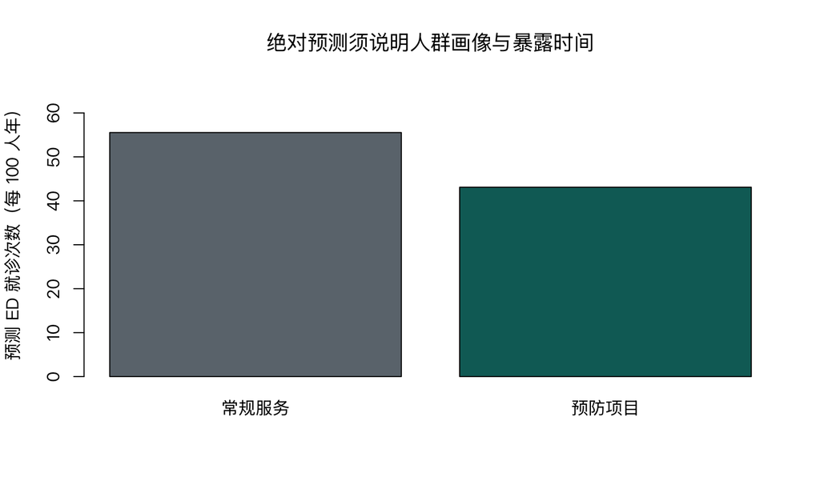

指定画像中两种项目的 Poisson 预测 ED 就诊次数（每 100 人年）

```r
set_count_plot_font()
barplot(
  height = profile$预测次数_每100人年,
  names.arg = profile$项目, col = c(palette_count["gray"], palette_count["teal"]),
  ylab = "预测 ED 就诊次数（每 100 人年）", ylim = c(0, max(profile$预测次数_每100人年) * 1.2),
  main = "绝对预测须说明人群画像与暴露时间"
)
```

## 2.3 置信区间与模型尺度

`predict(..., type = "response")` 给出均值预测，不自动回答所有不确定性问题。对线性预测子 $\eta=X^T\hat\beta+\log(t)$，可用 `predict(..., type = "link", se.fit = TRUE)` 在 log 均值尺度构造区间，再指数变换。它是**平均次数**的模型不确定性区间，不是单个新人的 prediction interval；后者还包含随机事件变异和参数不确定性。

```r
link_pred <- predict(poisson_fit, newdata = profile, type = "link", se.fit = TRUE)
profile$均值下限 <- exp(link_pred$fit - 1.96 * link_pred$se.fit)
profile$均值上限 <- exp(link_pred$fit + 1.96 * link_pred$se.fit)
profile$每100人年均值下限 <- 100 * profile$均值下限
profile$每100人年均值上限 <- 100 * profile$均值上限
knitr::kable(profile[, c("项目", "预测次数_每人年", "均值下限", "均值上限",
                         "预测次数_每100人年", "每100人年均值下限", "每100人年均值上限")],
             digits = 2, caption = "Poisson 预测均值的近似 95% 置信区间")
```

Poisson 预测均值的近似 95% 置信区间

| 项目 | 预测次数_每人年 | 均值下限 | 均值上限 | 预测次数_每100人年 | 每100人年均值下限 | 每100人年均值上限 |
| --- | --- | --- | --- | --- | --- | --- |
| 常规服务 | 0.56 | 0.51 | 0.60 | 55.5 | 51.2 | 60.2 |
| 预防项目 | 0.43 | 0.40 | 0.47 | 43.1 | 39.6 | 46.9 |

# 3 Poisson 假设与过度离散

## 3.1 均值等于方差是可检验的工作假设

Poisson 要求条件方差等于条件均值：$\operatorname{Var}(Y_i\mid X_i)=\mu_i$。Pearson 离散度是常用快速诊断：

$$\hat\phi_P=\frac{\sum_i (y_i-\hat\mu_i)^2/\hat\mu_i}{n-p}.$$

约为 1 与 Poisson 相容；明显大于 1 说明残差比假设更分散。它不是机械阈值：大样本下轻微偏离也会显著，且遗漏非线性、相关性或零机制都会影响它。

```r
pearson_resid <- residuals(poisson_fit, type = "pearson")
phi_pearson <- sum(pearson_resid^2) / df.residual(poisson_fit)
dispersion_table <- data.frame(
  指标 = c("Pearson 卡方", "残差自由度", "Pearson 离散度"),
  数值 = c(sum(pearson_resid^2), df.residual(poisson_fit), phi_pearson)
)
knitr::kable(dispersion_table, digits = 2, caption = "Poisson 的 Pearson 离散度诊断")
```

Poisson 的 Pearson 离散度诊断

| 指标 | 数值 |
| --- | --- |
| Pearson 卡方 | 3262.22 |
| 残差自由度 | 2394.00 |
| Pearson 离散度 | 1.36 |

常见的过度离散来源包括：未测量的易感性差异、遗漏交互或非线性、同一诊所/家庭的聚类、重复事件的依赖性、混合人群，以及零过多。相反，不能因为 $\hat\phi_P>1$ 就断言“必须 ZIP”；先检查数据质量、均值结构和聚类设计。

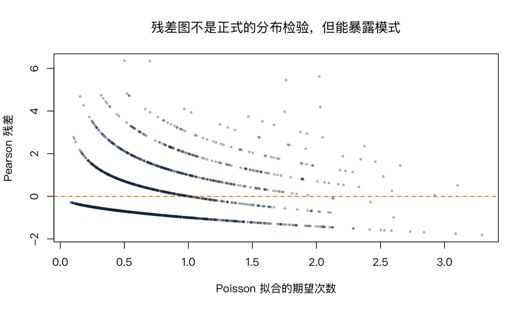

Poisson Pearson 残差与拟合均值：用于发现均值结构或离散度问题

```r
set_count_plot_font()
plot(
  fitted(poisson_fit), pearson_resid, pch = 16, cex = 0.55,
  col = grDevices::adjustcolor(palette_count["navy"], alpha.f = 0.35),
  xlab = "Poisson 拟合的期望次数", ylab = "Pearson 残差",
  main = "残差图不是正式的分布检验，但能暴露模式"
)
abline(h = 0, lty = 2, col = palette_count["vermillion"])
```

## 3.2 quasi-Poisson 与负二项：解决的不是同一件事

quasi-Poisson 保留 $E(Y\mid X)=\mu$ 和 log 链接，但把方差设为 $\phi\mu$，主要调整标准误；它没有完整似然，因此不能与 Poisson 用 AIC 比较。负二项常设：

$$\operatorname{Var}(Y_i\mid X_i)=\mu_i+\mu_i^2/\theta,$$

其中 $\theta$ 越小，额外异质性越大；它改变了分布与预测尾部，能用似然型 AIC。两者都不是对结构零的直接解释。

```r
quasi_fit <- update(poisson_fit, family = quasipoisson(link = "log"))
quasi_program <- summary(quasi_fit)[["coefficients"]]["program预防项目", ]

nb_available <- requireNamespace("MASS", quietly = TRUE)
if (nb_available) {
  nb_fit <- MASS::glm.nb(formula(poisson_fit), data = ed_data)
  nb_program <- summary(nb_fit)[["coefficients"]]["program预防项目", ]
  comparison_table <- data.frame(
    模型 = c("Poisson", "quasi-Poisson", "负二项"),
    项目_IRR = c(
      exp(coef(poisson_fit)["program预防项目"]),
      exp(quasi_program["Estimate"]), exp(nb_program["Estimate"])
    ),
    项目标准误 = c(
      summary(poisson_fit)[["coefficients"]]["program预防项目", "Std. Error"],
      quasi_program["Std. Error"], nb_program["Std. Error"]
    ),
    AIC = c(AIC(poisson_fit), NA, AIC(nb_fit))
  )
  knitr::kable(comparison_table, digits = 3,
               caption = "Poisson、quasi-Poisson 与负二项的比较（quasi 无 AIC）")
} else {
  cat("未安装 MASS，跳过负二项拟合；可运行 install.packages('MASS') 后重渲染。\n")
}
```

Poisson、quasi-Poisson 与负二项的比较（quasi 无 AIC）

| 模型 | 项目_IRR | 项目标准误 | AIC |
| --- | --- | --- | --- |
| Poisson | 0.776 | 0.049 | 5400 |
| quasi-Poisson | 0.776 | 0.057 | NA |
| 负二项 | 0.779 | 0.061 | 5234 |

聚类不是“多加一个分布”就解决 若同一人有多段观察、同一诊所服务多个参与者，独立个体的标准误会偏小。考虑以聚类为单位的稳健方差、GEE、随机效应/混合模型或按设计进行重抽样。负二项的个体层面异质性参数不自动等同于正确处理诊所相关性。

# 4 零很多，究竟意味着什么？

## 4.1 先描述零，再猜机制

计数数据出现许多零很常见：低基线率与短随访本身就能产生大量 Poisson 零。对指定协变量，Poisson 的零概率为 $P(Y=0)=\exp(-\mu)$。因此正确比较是“模型预测了多少零”，而不是仅报告零比例高。

```r
observed_zero <- mean(ed_data$ed_visits == 0)
poisson_zero_pred <- mean(dpois(0, lambda = fitted(poisson_fit)))
zero_table <- data.frame(
  项目 = c("观测零比例", "Poisson 平均预测零比例", "模拟中处于捕获范围外的比例（教学真值）"),
  比例 = c(observed_zero, poisson_zero_pred, mean(ed_data$outside_capture == 1))
)
knitr::kable(zero_table, digits = 3, caption = "零比例的描述：真实研究通常没有最后一行的机制标签")
```

零比例的描述：真实研究通常没有最后一行的机制标签

| 项目 | 比例 |
| --- | --- |
| 观测零比例 | 0.605 |
| Poisson 平均预测零比例 | 0.532 |
| 模拟中处于捕获范围外的比例（教学真值） | 0.318 |

结构零是“在本研究的事件生成/捕获过程下不可能发生或不可能被记录”的子群；抽样零是“仍在风险或可记录，但这个观察期恰好没发生”。在真实项目中，结构零的定义必须有领域依据，例如确实未覆盖的医疗网络、明确不符合观察资格的人群；不能通过模型事后给每个零贴标签。

## 4.2 ZIP 模型的组成与似然

ZIP 假定每人先以概率 $\pi_i$ 落在结构零组，否则以概率 $1-\pi_i$ 进入 Poisson 风险组：

$$P(Y_i=0)=\pi_i+(1-\pi_i)e^{-\mu_i},\quad
P(Y_i=y>0)=(1-\pi_i)\frac{e^{-\mu_i}\mu_i^y}{y!}.$$

通常以两个回归式连接协变量：

$$\log(\mu_i)=\log(t_i)+X_i^T\beta,\qquad
\operatorname{logit}(\pi_i)=Z_i^T\gamma.$$

这不是“零的逻辑回归 + 正数的 Poisson”两次独立拟合；零的观测同时可能来自两个部分，必须用联合似然。正数必来自 Poisson 风险组，但一个零的组别不可观测。

可识别性与命名的克制 ZIP 能把数据拟合成两个潜在组，不代表两个组在科学上真实、可稳定区分。若 $X$ 与 $Z$ 完全相同、样本中正数很少或协变量强烈分离，两个部分可能高度不稳定。最好让零部分由明确的捕获/资格机制驱动，并做替代模型与敏感性分析。

# 5 用 base R 从头估计 ZIP

## 5.1 设计两个部分和稳定对数似然

为便于教学，计数部分使用项目、吸烟、严重度、农村、年龄和人年；零部分使用就医障碍与农村居住，代表与捕获范围相关的变量。现实研究应在分析计划中说明每个部分的变量、时间顺序和科学依据，而不是根据 AIC 反复筛选。

```r
zip_count_formula <- ~ program + smoking + severity + rural + age10
zip_zero_formula <- ~ access_barrier + rural
X_zip <- model.matrix(zip_count_formula, data = ed_data)
Z_zip <- model.matrix(zip_zero_formula, data = ed_data)
y_zip <- ed_data$ed_visits
offset_zip <- log(ed_data$person_years)

# theta = (beta, gamma)。零值以 log-sum-exp 计算，避免 exp(-mu) 下溢或直接求和失稳。
zip_negloglik <- function(theta, y, X, Z, offset) {
  p_beta <- ncol(X)
  beta <- theta[seq_len(p_beta)]
  gamma <- theta[p_beta + seq_len(ncol(Z))]
  eta_count <- drop(offset + X %*% beta)
  # 只排除超出双精度指数函数数值域的参数，不改变可计算范围内的模型。
  if (any(!is.finite(eta_count)) || any(abs(eta_count) > 700)) return(1e100)
  mu <- exp(eta_count)
  eta_zero <- drop(Z %*% gamma)
  log_pi <- plogis(eta_zero, log.p = TRUE)
  log_one_minus_pi <- plogis(-eta_zero, log.p = TRUE)
  is_zero <- y == 0
  loglik <- numeric(length(y))
  loglik[is_zero] <- log_sum_exp2(
    log_pi[is_zero], log_one_minus_pi[is_zero] - mu[is_zero]
  )
  loglik[!is_zero] <- log_one_minus_pi[!is_zero] +
    dpois(y[!is_zero], lambda = mu[!is_zero], log = TRUE)
  if (any(!is.finite(loglik))) return(1e100)
  -sum(loglik)
}

# Poisson 系数提供计数部分的稳定起点；零部分使用多个起点降低局部最优风险。
poisson_start <- coef(glm(
  ed_visits ~ program + smoking + severity + rural + age10 + offset(log(person_years)),
  family = poisson, data = ed_data
))
poisson_zero_start <- mean(exp(-fitted(poisson_fit)))
pi_start <- (mean(y_zip == 0) - poisson_zero_start) / (1 - poisson_zero_start)
pi_start <- pmin(pmax(pi_start, 0.02), 0.80)
zero_intercept_starts <- unique(c(qlogis(pi_start), qlogis(c(0.05, 0.25, 0.50))))
zip_starts <- lapply(
  zero_intercept_starts,
  function(intercept) c(poisson_start, intercept, rep(0, ncol(Z_zip) - 1L))
)
stopifnot(all(vapply(
  zip_starts,
  length,
  integer(1)
) == ncol(X_zip) + ncol(Z_zip)))
```

## 5.2 执行最大似然、Hessian 与标准误

```r
zip_candidates <- lapply(zip_starts, function(start) {
  optim(
    par = start, fn = zip_negloglik, method = "BFGS",
    y = y_zip, X = X_zip, Z = Z_zip, offset = offset_zip,
    hessian = TRUE, control = list(maxit = 2000, reltol = 1e-10)
  )
})
valid_candidate <- vapply(
  zip_candidates,
  function(candidate) candidate$convergence == 0 && is.finite(candidate$value),
  logical(1)
)
if (!any(valid_candidate)) {
  stop("所有 ZIP 优化起点都未收敛；应检查尺度、模型复杂度与数据机制。", call. = FALSE)
}
valid_fits <- zip_candidates[valid_candidate]
zip_optim <- valid_fits[[which.min(vapply(valid_fits, `[[`, numeric(1), "value"))]]

hessian_symmetric <- (zip_optim$hessian + t(zip_optim$hessian)) / 2
hessian_eigen <- eigen(hessian_symmetric, symmetric = TRUE, only.values = TRUE)$values
hessian_condition <- max(hessian_eigen) / min(hessian_eigen)
if (any(!is.finite(hessian_eigen)) || min(hessian_eigen) <= 0 ||
    !is.finite(hessian_condition) || hessian_condition > 1e10) {
  stop("ZIP Hessian 不够正定或条件数过大；当前 Wald 标准误不可靠。", call. = FALSE)
}
zip_vcov <- solve(hessian_symmetric)
zip_se <- sqrt(diag(zip_vcov))

zip_gradient <- vapply(seq_along(zip_optim$par), function(j) {
  step <- 1e-5 * max(1, abs(zip_optim$par[j]))
  upper <- lower <- zip_optim$par
  upper[j] <- upper[j] + step
  lower[j] <- lower[j] - step
  (zip_negloglik(upper, y_zip, X_zip, Z_zip, offset_zip) -
     zip_negloglik(lower, y_zip, X_zip, Z_zip, offset_zip)) / (2 * step)
}, numeric(1))
zip_gradient_max <- max(abs(zip_gradient))
if (!is.finite(zip_gradient_max) || zip_gradient_max > 0.01) {
  stop("ZIP 解的数值梯度仍过大；当前结果不可报告。", call. = FALSE)
}
p_beta <- ncol(X_zip)
zip_beta <- zip_optim$par[seq_len(p_beta)]
zip_gamma <- zip_optim$par[p_beta + seq_len(ncol(Z_zip))]
zip_beta_se <- zip_se[seq_len(p_beta)]
zip_gamma_se <- zip_se[p_beta + seq_len(ncol(Z_zip))]

zip_status <- data.frame(
  指标 = c("收敛代码（0 为成功）", "尝试的起点数", "负对数似然",
           "最大绝对数值梯度", "最小 Hessian 特征值", "Hessian 条件数"),
  数值 = c(zip_optim$convergence, length(zip_starts), zip_optim$value,
           zip_gradient_max, min(hessian_eigen), hessian_condition)
)
knitr::kable(zip_status, digits = 4, caption = "ZIP 优化与 Hessian 检查")
```

ZIP 优化与 Hessian 检查

| 指标 | 数值 |
| --- | --- |
| 收敛代码（0 为成功） | 0.00e+00 |
| 尝试的起点数 | 4.00e+00 |
| 负对数似然 | 2.53e+03 |
| 最大绝对数值梯度 | 4.00e-04 |
| 最小 Hessian 特征值 | 1.78e+01 |
| Hessian 条件数 | 1.71e+02 |

这里 Hessian 的逆是观测信息矩阵近似，Wald 标准误依赖局部二次近似。对边界参数、很小样本或不稳定混合模型，轮廓似然、bootstrap 或重新设计模型常比盲目报告 Wald 区间更诚实。

```r
zip_count_table <- data.frame(
  计数部分变量 = colnames(X_zip),
  在风险组率比 = exp(zip_beta),
  下限 = exp(zip_beta - 1.96 * zip_beta_se),
  上限 = exp(zip_beta + 1.96 * zip_beta_se),
  P值 = 2 * pnorm(abs(zip_beta / zip_beta_se), lower.tail = FALSE)
)
zip_zero_table <- data.frame(
  零部分变量 = colnames(Z_zip),
  结构零优势比 = exp(zip_gamma),
  下限 = exp(zip_gamma - 1.96 * zip_gamma_se),
  上限 = exp(zip_gamma + 1.96 * zip_gamma_se),
  P值 = 2 * pnorm(abs(zip_gamma / zip_gamma_se), lower.tail = FALSE)
)
zip_count_effects <- zip_count_table[zip_count_table$计数部分变量 != "(Intercept)", ]
zip_zero_effects <- zip_zero_table[zip_zero_table$零部分变量 != "(Intercept)", ]
knitr::kable(zip_count_effects, digits = 3,
             caption = "ZIP 计数部分：条件于非结构零组的率比")
```

ZIP 计数部分：条件于非结构零组的率比

|  | 计数部分变量 | 在风险组率比 | 下限 | 上限 | P值 |
| --- | --- | --- | --- | --- | --- |
| program预防项目 | program预防项目 | 0.77 | 0.693 | 0.854 | 0.000 |
| smoking吸烟 | smoking吸烟 | 1.43 | 1.273 | 1.596 | 0.000 |
| severity | severity | 1.46 | 1.380 | 1.534 | 0.000 |
| rural农村 | rural农村 | 1.16 | 1.017 | 1.322 | 0.027 |
| age10 | age10 | 1.10 | 1.053 | 1.152 | 0.000 |

```r
knitr::kable(zip_zero_effects, digits = 3,
             caption = "ZIP 零部分：属于结构零组的优势比（需有机制依据）")
```

ZIP 零部分：属于结构零组的优势比（需有机制依据）

|  | 零部分变量 | 结构零优势比 | 下限 | 上限 | P值 |
| --- | --- | --- | --- | --- | --- |
| 2 | access_barrier有障碍 | 3.78 | 2.77 | 5.17 | 0 |
| 3 | rural农村 | 2.12 | 1.49 | 3.02 | 0 |

表中不展示截距：计数截距指数化后是参考画像每人年的基线率，零部分截距指数化后是参考画像的结构零基线 odds；它们都不是协变量变化的比值。

## 5.3 两个部分的解释不能混为一谈

- **计数部分的 IRR**：在模型定义的非结构零（风险/可捕获）人群中，协变量变化对应的条件发生率比。
- **零部分的 OR**：协变量变化对应“属于结构零潜在组”的优势比，不是“观测到零”的优势比。
- **边际均值**：$E(Y_i\mid X_i,Z_i)=(1-\pi_i)\mu_i$，同时受两个部分影响；这通常更接近服务量预测。
- **零概率**：$P(Y_i=0)=\pi_i+(1-\pi_i)e^{-\mu_i}$，不是单独的 $\pi_i$。

零部分 OR 常不直观，尤其事件不罕见时；对决策者，优先给出明确人群和暴露时间下的 $\mu$、$\pi$、边际均值以及零概率。

# 6 ZIP 的预测、频数与校准

## 6.1 为每个人计算四个不同的量

```r
zip_eta_count <- drop(offset_zip + X_zip %*% zip_beta)
zip_mu <- exp(zip_eta_count)
zip_pi <- inv_logit(drop(Z_zip %*% zip_gamma))
zip_mean <- (1 - zip_pi) * zip_mu
zip_p0 <- zip_pi + (1 - zip_pi) * exp(-zip_mu)

pred_summary <- data.frame(
  量 = c("在风险组条件均值 mu", "结构零概率 pi", "边际期望次数", "观测到零的概率"),
  平均值 = c(mean(zip_mu), mean(zip_pi), mean(zip_mean), mean(zip_p0)),
  最小值 = c(min(zip_mu), min(zip_pi), min(zip_mean), min(zip_p0)),
  最大值 = c(max(zip_mu), max(zip_pi), max(zip_mean), max(zip_p0))
)
knitr::kable(pred_summary, digits = 3, caption = "ZIP 的四种预测量不可互换")
```

ZIP 的四种预测量不可互换

| 量 | 平均值 | 最小值 | 最大值 |
| --- | --- | --- | --- |
| 在风险组条件均值 mu | 1.074 | 0.103 | 5.670 |
| 结构零概率 pi | 0.326 | 0.187 | 0.648 |
| 边际期望次数 | 0.716 | 0.060 | 3.814 |
| 观测到零的概率 | 0.602 | 0.203 | 0.944 |

```r
zip_profile_data <- profile[rep(seq_len(nrow(profile)), each = 2), ]
zip_profile_data$access_barrier <- factor(
  rep(c("无明显障碍", "有障碍"), times = 2),
  levels = levels(ed_data$access_barrier)
)
X_profile <- model.matrix(zip_count_formula, data = zip_profile_data)
Z_profile <- model.matrix(zip_zero_formula, data = zip_profile_data)
profile_mu <- exp(log(zip_profile_data$person_years) + drop(X_profile %*% zip_beta))
profile_pi <- inv_logit(drop(Z_profile %*% zip_gamma))
profile_zip <- data.frame(
  项目 = zip_profile_data$项目,
  就医障碍 = zip_profile_data$access_barrier,
  风险组条件均值_mu = profile_mu,
  结构零概率_pi = profile_pi,
  边际期望次数 = (1 - profile_pi) * profile_mu,
  边际期望次数_每100人年 = 100 * (1 - profile_pi) * profile_mu,
  观测零概率 = profile_pi + (1 - profile_pi) * exp(-profile_mu)
)
knitr::kable(profile_zip, digits = 3,
             caption = "指定个体画像在 1 人年内的 ZIP 分量与边际预测；率另换算为每 100 人年")
```

指定个体画像在 1 人年内的 ZIP 分量与边际预测；率另换算为每 100 人年

|  | 项目 | 就医障碍 | 风险组条件均值_mu | 结构零概率_pi | 边际期望次数 | 边际期望次数_每100人年 | 观测零概率 |
| --- | --- | --- | --- | --- | --- | --- | --- |
| 1 | 常规服务 | 无明显障碍 | 0.750 | 0.187 | 0.610 | 61.0 | 0.571 |
| 1.1 | 常规服务 | 有障碍 | 0.750 | 0.465 | 0.402 | 40.2 | 0.717 |
| 2 | 预防项目 | 无明显障碍 | 0.577 | 0.187 | 0.470 | 47.0 | 0.643 |
| 2.1 | 预防项目 | 有障碍 | 0.577 | 0.465 | 0.309 | 30.9 | 0.765 |

```r
# 参数模拟保留 beta、gamma 及两个部分之间的完整交叉协方差。
set.seed(20260821)
n_draws <- 1200
coefficient_draws <- matrix(
  rnorm(n_draws * length(zip_optim$par)), nrow = n_draws
) %*% chol(zip_vcov)
coefficient_draws <- sweep(coefficient_draws, 2, zip_optim$par, "+")

beta_draws <- coefficient_draws[, seq_len(p_beta), drop = FALSE]
gamma_draws <- coefficient_draws[, p_beta + seq_len(ncol(Z_zip)), drop = FALSE]
mu_draws <- exp(sweep(
  beta_draws %*% t(X_profile),
  2,
  log(zip_profile_data$person_years),
  "+"
))
pi_draws <- inv_logit(gamma_draws %*% t(Z_profile))
marginal_draws <- (1 - pi_draws) * mu_draws
zero_probability_draws <- pi_draws + (1 - pi_draws) * exp(-mu_draws)

profile_zip$边际均值下限 <- apply(marginal_draws, 2, quantile, 0.025)
profile_zip$边际均值上限 <- apply(marginal_draws, 2, quantile, 0.975)
profile_zip$零概率下限 <- apply(zero_probability_draws, 2, quantile, 0.025)
profile_zip$零概率上限 <- apply(zero_probability_draws, 2, quantile, 0.975)
knitr::kable(profile_zip, digits = 3,
             caption = "ZIP 画像预测及参数不确定性的近似 95% 区间")
```

ZIP 画像预测及参数不确定性的近似 95% 区间

|  | 项目 | 就医障碍 | 风险组条件均值_mu | 结构零概率_pi | 边际期望次数 | 边际期望次数_每100人年 | 观测零概率 | 边际均值下限 | 边际均值上限 | 零概率下限 | 零概率上限 |
| --- | --- | --- | --- | --- | --- | --- | --- | --- | --- | --- | --- |
| 1 | 常规服务 | 无明显障碍 | 0.750 | 0.187 | 0.610 | 61.0 | 0.571 | 0.555 | 0.668 | 0.543 | 0.600 |
| 1.1 | 常规服务 | 有障碍 | 0.750 | 0.465 | 0.402 | 40.2 | 0.717 | 0.347 | 0.462 | 0.680 | 0.755 |
| 2 | 预防项目 | 无明显障碍 | 0.577 | 0.187 | 0.470 | 47.0 | 0.643 | 0.427 | 0.515 | 0.616 | 0.668 |
| 2.1 | 预防项目 | 有障碍 | 0.577 | 0.465 | 0.309 | 30.9 | 0.765 | 0.267 | 0.357 | 0.733 | 0.796 |

这些区间传播了回归系数的不确定性，并保留两个 ZIP 部分之间的交叉协方差；它们不是未来个体真实次数的预测区间，也不包含模型选择、结构假设或外部推广的不确定性。

## 6.2 观测频数与预测频数

只比较平均数可能掩盖尾部和零的错误。下面把每人的预测概率加总，得到各计数的期望人数；尾部合并为“6 次及以上”以避免稀疏单元。ZIP 的频数概率由混合分布给出。

```r
count_bins <- 0:5
obs_frequency <- c(tabulate(pmin(y_zip, 6) + 1, nbins = 7))
poisson_expected <- sapply(count_bins, function(k) sum(dpois(k, fitted(poisson_fit))))
zip_expected <- sapply(count_bins, function(k) {
  if (k == 0) sum(zip_p0) else sum((1 - zip_pi) * dpois(k, zip_mu))
})
poisson_tail <- nrow(ed_data) - sum(poisson_expected)
zip_tail <- nrow(ed_data) - sum(zip_expected)
frequency_table <- data.frame(
  次数类别 = c(as.character(count_bins), "6 次及以上"),
  观测人数 = obs_frequency,
  Poisson_期望人数 = c(poisson_expected, poisson_tail),
  ZIP_期望人数 = c(zip_expected, zip_tail)
)
knitr::kable(frequency_table, digits = 1, caption = "观测与模型预测的计数频数：零和尾部都应检查")
```

观测与模型预测的计数频数：零和尾部都应检查

| 次数类别 | 观测人数 | Poisson_期望人数 | ZIP_期望人数 |
| --- | --- | --- | --- |
| 0 | 1451 | 1276.1 | 1445.9 |
| 1 | 498 | 718.8 | 506.2 |
| 2 | 257 | 274.0 | 257.8 |
| 3 | 120 | 90.9 | 113.2 |
| 4 | 47 | 28.3 | 46.6 |
| 5 | 15 | 8.5 | 18.6 |
| 6 次及以上 | 12 | 3.4 | 11.7 |

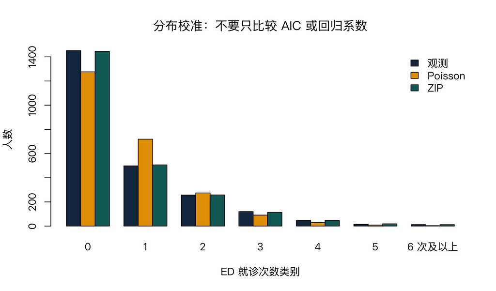

观测频数与 Poisson、ZIP 预测频数的比较

```r
set_count_plot_font()
barplot(
  t(as.matrix(frequency_table[, c("观测人数", "Poisson_期望人数", "ZIP_期望人数")])),
  beside = TRUE, names.arg = frequency_table$次数类别,
  col = c(palette_count["navy"], palette_count["orange"], palette_count["teal"]),
  ylab = "人数", xlab = "ED 就诊次数类别",
  main = "分布校准：不要只比较 AIC 或回归系数"
)
legend("topright", legend = c("观测", "Poisson", "ZIP"),
       fill = c(palette_count["navy"], palette_count["orange"], palette_count["teal"]), bty = "n")
```

## 6.3 按预测风险分组校准

校准回答“同样预测为 0.4 次的人群，实际平均是否约为 0.4 次？”它不是证明模型机制正确的检验。这里按 ZIP 边际均值十分位分组，比较观测平均次数、Poisson 平均预测和 ZIP 平均预测；在真实分析中还应预先保留验证样本或做交叉验证。

```r
calibration_group <- cut(
  zip_mean,
  breaks = unique(quantile(zip_mean, probs = seq(0, 1, 0.1))),
  include.lowest = TRUE
)
calibration <- aggregate(
  cbind(观测平均次数 = y_zip, Poisson预测 = fitted(poisson_fit), ZIP预测 = zip_mean) ~ calibration_group,
  FUN = mean
)
calibration$n <- as.integer(table(calibration_group))
knitr::kable(calibration, digits = 3, caption = "按 ZIP 边际预测十分位的均值校准")
```

按 ZIP 边际预测十分位的均值校准

| calibration_group | 观测平均次数 | Poisson预测 | ZIP预测 | n |
| --- | --- | --- | --- | --- |
| [0.0604,0.243] | 0.179 | 0.224 | 0.179 | 240 |
| (0.243,0.319] | 0.300 | 0.333 | 0.281 | 240 |
| (0.319,0.407] | 0.392 | 0.405 | 0.361 | 240 |
| (0.407,0.49] | 0.396 | 0.495 | 0.450 | 240 |
| (0.49,0.584] | 0.546 | 0.580 | 0.536 | 240 |
| (0.584,0.696] | 0.600 | 0.645 | 0.639 | 240 |
| (0.696,0.845] | 0.729 | 0.768 | 0.768 | 240 |
| (0.845,1.04] | 0.987 | 0.905 | 0.943 | 240 |
| (1.04,1.37] | 1.167 | 1.120 | 1.189 | 240 |
| (1.37,3.81] | 1.858 | 1.680 | 1.811 | 240 |

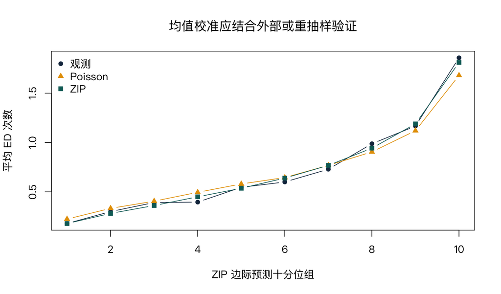

按预测十分位的观测平均次数与两种模型平均预测

```r
set_count_plot_font()
plot(
  seq_len(nrow(calibration)), calibration$观测平均次数, type = "b", pch = 16,
  col = palette_count["navy"], ylim = range(calibration[, c("观测平均次数", "Poisson预测", "ZIP预测")]),
  xlab = "ZIP 边际预测十分位组", ylab = "平均 ED 次数",
  main = "均值校准应结合外部或重抽样验证"
)
lines(seq_len(nrow(calibration)), calibration$Poisson预测, type = "b", pch = 17, col = palette_count["orange"])
lines(seq_len(nrow(calibration)), calibration$ZIP预测, type = "b", pch = 15, col = palette_count["teal"])
legend("topleft", legend = c("观测", "Poisson", "ZIP"), pch = c(16, 17, 15),
       col = c(palette_count["navy"], palette_count["orange"], palette_count["teal"]), bty = "n")
```

## 6.4 AIC 有用，但不是裁判

对同一数据、同一响应且有定义良好完整似然的模型，较小 AIC 表示在拟合优度与参数数目之间较好的近似预测折衷。它不检验结构零的科学真实性，不惩罚不良的队列设计，也不能比较 quasi-Poisson。混合模型的非嵌套、边界参数和不同支持集会让常规似然比检验更加棘手。

```r
zip_aic <- 2 * length(zip_optim$par) + 2 * zip_optim$value
aic_table <- data.frame(
  模型 = c("Poisson", if (nb_available) "负二项" else NULL, "ZIP（base R 实现）"),
  AIC = c(AIC(poisson_fit), if (nb_available) AIC(nb_fit) else NULL, zip_aic)
)
knitr::kable(aic_table, digits = 1,
             caption = "AIC 仅作候选模型的一个比较维度；quasi-Poisson 不在表中")
```

AIC 仅作候选模型的一个比较维度；quasi-Poisson 不在表中

| 模型 | AIC |
| --- | --- |
| Poisson | 5400 |
| 负二项 | 5234 |
| ZIP（base R 实现） | 5086 |

# 7 ZIP、hurdle 和其他分析策略

## 7.1 Hurdle 模型回答的是另一种过程假设

| 特征 | ZIP | Hurdle（两部分） |
| --- | --- | --- |
| 零的来源 | 结构零或 Poisson 抽样零 | 所有零都由“是否跨过门槛”过程产生 |
| 正数部分 | 普通 Poisson（可在理论上产生零） | 零截断 Poisson/负二项 |
| 零与正数的关系 | 零的潜在来源不可观测 | 先发生任意一次，再决定正数大小 |
| 适合的科学故事 | 未覆盖系统者 vs 可捕获风险者 | 接触服务的障碍 vs 接触后使用强度 |

例如，“是否进入任何参与医院”与“进入后急诊次数”可能支持 hurdle；“部分人始终不在本系统的捕获框内”可能支持 ZIP。两者都应从研究过程出发，而不是从零柱最高这一事实反推。

## 7.2 设计、聚类与因果推断的边界

若项目按社区实施，个人结果可能在社区内相关；若每人多次年度随访，数据也是纵向的。可考虑 GEE、混合效应负二项/ZIP、带随机效应的两部分模型或以社区为重抽样单位。模型选择须与抽样单位、暴露分配单位和目标推断总体一致。

对于非随机项目评估，还要在建模前明确目标试验：资格、时间零点、治疗策略、随访、结局、混杂控制和估计量。倾向评分、标准化、加权或 g 方法可用于处理已测量混杂；零膨胀模型仍只是结局模型的一部分。参见 因果推断 与 倾向评分匹配 模块。

# 8 从问题到报告：可审核工作流

## 8.1 推荐分析路径

1. **定义事件与人年**：明确事件窗口、重复计数规则、进入/退出规则和数据捕获边界。
2. **描述分布**：按暴露组报告人数、人年、总次数、粗率、零比例和高计数尾部。
3. **预先定义均值结构**：基于时间顺序和领域知识选择混杂因素、非线性和交互；不要用结局驱动变量筛选。
4. **拟合基准 Poisson**：使用 offset，并报告 IRR、绝对预测、Pearson 离散度和残差图。
5. **处理额外变异/相关性**：依据目标分别考虑稳健标准误、quasi、负二项、GEE 或混合模型。
6. **提出并审计零机制**：说明什么人为什么可能结构性为零；比较 Poisson 预测零与观测零。
7. **如使用 ZIP/hurdle**：报告两个公式、优化收敛、识别风险、分量预测、频数与校准。
8. **验证与敏感性分析**：比较候选分布、改变均值结构、检查高影响观察、做重抽样或外部验证。
9. **透明报告边界**：说明数据来源、缺失、聚类、未测量混杂、模型依赖性与结果可推广范围。

## 8.2 报告结果的句式模板

> 在 $N=...$ 名符合资格的参与者中，累计随访 … 人年，观察到 … 次呼吸系统 ED 就诊（粗率 …/人年；零比例 …）。使用以对数人年为 offset 的 [Poisson/负二项/ZIP] 回归，调整 … 后，预防项目相对常规服务的 [条件 IRR/边际预测差异] 为 …（95% CI …）。[若 ZIP：在风险组计数部分的 IRR 为 …；结构零部分建模的是 …，不应解释为观测零的 OR。] Pearson 离散度为 …；观测—预测频数与分组校准见图 …。结果描述条件关联；由于 …，不能作出/需谨慎作出因果解释。

## 8.3 常见错误及修正

| 常见错误 | 为什么不对 | 修正 |
| --- | --- | --- |
| 不同随访时长却不设 offset | 把暴露机会混入组别差异 | 核实人年，使用 `offset(log(person_years))` |
| 把 IRR 说成风险比或绝对减少 | 估计量与尺度被改变 | 明确“率比”，另报标准化绝对预测 |
| 看到离散度大就自动 ZIP | 过度离散有许多来源 | 先检查均值结构、聚类、NB/quasi 和零机制 |
| 把 ZIP 零部分 OR 称作“零的 OR” | 观测零来自两种成分 | 报告 $\pi$、$P(Y=0)$ 与边际均值 |
| 用 AIC 宣称发现结构零群体 | AIC 不提供机制证据 | 用领域定义、数据流程和敏感性分析支持 |
| 忽略 Hessian/收敛警告 | 混合模型可处在边界或不可识别 | 检查参数、起点、模型复杂度和不确定性 |
| 用个体独立模型分析诊所聚类数据 | 标准误和模型结构可能错误 | 按设计使用 GEE、混合模型或聚类重抽样 |

# 9 知识检查与练习

## 快速自测

1. 某人被观察 0.5 人年、另一个人被观察 2 人年；为什么简单比较其原始次数可能不公平？
2. Poisson 的 Pearson 离散度为 2.4，能否仅据此判定数据存在结构零？
3. ZIP 中 $\pi_i=0.30$、$\mu_i=1.50$，该人的边际均值与观测零概率分别是什么？
4. 若研究问题是“是否首次进入任何急诊”，为什么本页的重复事件率模型未必最合适？

**查看答案**

1. 后者有四倍事件观察机会；应以人年为分母，并在率模型中使用 offset。
2. 不能。它说明残差变异高于 Poisson 工作假设，可能来自遗漏变量、异质性、聚类、非线性或零机制。
3. 边际均值为 $(1-0.30)\times1.50=1.05$；零概率为 $0.30+0.70e^{-1.50}\approx0.456$。
4. 该问题是首次事件/风险或时间到事件问题；应明确删失与时间零点，考虑二项或生存分析，而不是把重复次数当作唯一结局。

## 练习：修改并审计模型

1. 将计数部分加入 `program:severity` 交互，说明交互项的 IRR 在什么条件下解释；比较指定画像的边际预测，而不是仅看 P 值。
2. 将零部分的 `access_barrier` 去掉，比较观测—预测零人数、AIC 与实际数据流程的合理性。哪一个证据最重要？
3. 令所有人年固定为 1，重新拟合。哪些估计量改变？这说明为何应保留原始暴露时间？
4. 设想数据来自 20 个诊所。写出至少两种会改变推断的相关性处理方案，并说明各自的边际/条件解释。

**练习讨论要点**

1. 交互 IRR 修饰的是项目的条件率比；主效应只适用于参考严重度。应画出每个严重度、同一人年和协变量画像的边际均值与区间。
2. AIC 和零频数都是诊断；最优先的是是否真的存在由就医障碍刻画的捕获范围机制。没有机制依据时，不应把更低 AIC 写成“发现结构零”。
3. 率模型中的协变量 IRR 在正确模型下可能相近，但均值、截距、拟合、标准误和预测会改变；真实人年承载了可观察事件机会。
4. 可用人口平均的 GEE（聚类稳健方差）或诊所随机截距的混合模型；前者常解释为边际关联，后者为给定随机效应的条件关联。选择由 estimand 与设计决定。

# 10 速查表与提交前清单

## 速查表

| 目标 | 关键量/代码 | 解释提醒 |
| --- | --- | --- |
| 率模型 | `glm(y ~ x + offset(log(py)), family=poisson)` | offset 系数固定为 1 |
| IRR | `exp(coef(fit))` | 条件率比，非风险比 |
| Poisson 离散度 | `sum(residuals(fit,"pearson")^2)/df.residual(fit)` | 大于 1 需查原因，不是 ZIP 诊断 |
| quasi-Poisson | `family = quasipoisson` | 调整方差；无 AIC |
| 负二项 | `MASS::glm.nb(...)` | 允许二次均值—方差关系 |
| ZIP 边际均值 | `(1 - pi) * mu` | 同时受两个部分影响 |
| ZIP 观测零概率 | `pi + (1 - pi) * exp(-mu)` | 不等于 `pi` |
| 频数检查 | 逐人预测概率后求和 | 同时看零、中心与尾部 |

## 提交前清单

- 事件定义、时间零点、退出规则和人年计算可复现；
- 研究问题明确是次数、率、风险还是首次事件；
- offset 与暴露单位匹配，且没有把暴露时间误作普通协变量；
- 协变量由因果/领域知识和时间顺序决定；
- 报告了人数、人年、次数、粗率、零比例和高计数尾部；
- 解释了离散度、聚类与缺失，而非仅给一个回归表；
- 若用 ZIP/hurdle，写明每部分的科学机制和公式；
- ZIP 优化已收敛，Hessian/不确定性与识别风险已审计；
- 给出可理解的绝对预测、观测—预测频数及校准；
- 不把条件关联、模型机制或 AIC 写成因果/生物学事实。